# Text Mining

Claire Liu

### Preprocessing: Get Data

##### import libaries

```r
library(tidyverse)
library(rvest)
library(stringr)
library(jiebaR)
library(tm)
library(tmcn)
library(XML)
library(httr)
```

##### get session

- grepl: 比較字串吻合
- html_session: 模擬網頁操作

```r
if(!dir.exists("./DATA")) {
  # 合成 ptt 網址和看板
  ptt.url <- "https://www.ptt.cc"
  page.url <- str_c(ptt.url, "/bbs/WomenTalk")
  page.session <- html_session(url = page.url)

  # 確認看板需不需要授權已滿 18 歲
  if(grepl("ask", page.session$url))
    {
      page.form <- page.session %>% html_node("form") %>% html_form()
      page <- submit_form( session = page.session, form = page.form, submit = "yes")
    } else {
      page <- page.session
    }

  # 取得最新的頁數
  page.latest <- page %>%
    html_nodes("a") %>% html_attr("href") %>%
    str_subset("index[0-9]{2,}\\.html") %>% str_extract("[0-9]+") %>% as.numeric()

  page.latest
}
```

##### Get hyperlinks to all articles

- link: 是所有頁面的超連結
- links.article: 是所有所有頁面上的文章的超連結

```r
if(!dir.exists("./DATA")) {
  links.article <- NULL
  page.length <- 10
  for (page.index in page.latest:(page.latest - page.length)) {
    link <- str_c(page.url, "/index", page.index, ".html")
    links.article <- c( links.article, page %>% jump_to(link) %>%
                        html_nodes("a") %>% html_attr("href") %>%
                        str_subset("[A-z]\\.[0-9]+\\.[A-z]\\.[A-z0-9]+\\.html"))
  }
  # 過濾重複的文章連結
  links.article <- unique(links.article)
}
```

##### Get articles contents and parsing data

將文章和留言分別以時間記錄在不同的檔案中，  
要從 PTT 來觀察人在不同時間點所用字的情感或討論的事物有何不同。

- 注意：八卦版留言有 IP 的問題尚未修改

```r
if(!dir.exists("./DATA")) {
  dir.create("./DATA")
  for(url in links.article) {
    url  = paste0(ptt.url, url)
    #tag  = html_node(read_html(url), 'div#main-content.bbs-screen.bbs-content')
    #text = toUTF8(html_text(tag))

    # 連結⾄⽂章網址
    temp.html <- page %>% jump_to(url)

    # 開頭部分元素，包含資訊: 發文者[1]、看板[2]、標題[3]、發文日期時間[4]
    article.header <- temp.html %>%
      html_nodes("span.article-meta-value") %>%
      html_text()

    article.title = article.header[3]
    article.datetime = article.header[4]

    # 取得內文
    article.content <- temp.html %>%
      html_nodes(xpath = '//div[@id="main-content"]/node()[not(self::div|self::span[@class="f2"])]') %>%
      html_text(trim = TRUE) %>%
      str_c(collapse = "")

    hour <- str_sub(article.datetime, 5) %>% parse_datetime("%b %d %H:%M:%S %Y")
    hour <- format(hour, "%H")
    name <- paste0('DATA/', hour, ".txt")
    write(article.content, name, append = TRUE)

    # 擷取推⽂(in span):
    article.push <- temp.html %>% html_nodes("div.push")

    # 推文種類(push-tag)、推文者(push-userid)、推文內容(push-content)、推文時間(push-ipdatetime)
    push.table.datetime <- article.push %>% html_nodes("span.push-ipdatetime") %>%
      html_text(trim = TRUE)
    push.table.content <- article.push %>% html_nodes("span.push-content") %>%
      html_text(trim = TRUE) %>% str_sub(3)

    for(i in 1: length(article.push))
    {
      hour <- str_c("2018/", push.table.datetime[i]) %>% parse_datetime("%Y/%m/%d %H:%M")
      hour <- format(hour, "%H")
      doc  <- push.table.content[i]
      name <- paste0('DATA/', hour, ".txt")
      write(doc, name, append = TRUE)
    }
  }
}
```

##### clean data & 斷詞分析

- 以每小時做分組
- removePunctuation 移除符號、removeNumbers & function 移除英文和數字、segmentCN 斷詞

```r
# corpus to tdm
# 轉向量矩陣
docs.corpus <- Corpus(DirSource("./Data/"))
docs.corpus <- tm_map(docs.corpus, removePunctuation)
docs.corpus <- tm_map(docs.corpus, removeNumbers)
docs.corpus <- tm_map(docs.corpus, function(word) {
    gsub("[A-Za-z0-9]", "", word)
})
docs.seg <- tm_map(docs.corpus, segmentCN)
docs.tdm <- TermDocumentMatrix(docs.seg, control = list())
#inspect(docs.tdm)
```

做 matrix 轉換，讓 TF-IDF 可以進行

```r
mixseg = worker()
jieba_tokenizer = function(d)
{
  unlist( segment(d[[1]], mixseg) )
}
seg = lapply(docs.corpus, jieba_tokenizer)

count_token = function(d)
{
  as.data.frame(table(d))
}
tokens = lapply(seg, count_token)

n = length(seg)
TDM = tokens[[1]]
colNames <- names(seg)
colNames <- gsub(".txt", "", colNames)
for( id in c(2:n) )
{
  TDM = merge(TDM, tokens[[id]], by="d", all = TRUE)
  names(TDM) = c('d', colNames[1:id])
}
TDM[is.na(TDM)] <- 0
library(knitr)
kable(head(TDM))
```

| d | 00 | 01 | 02 | 03 | 04 | 05 | 06 | 07 | 08 | 09 | 10 | 11 | 12 | 13 | 14 | 15 | 16 | 17 | 18 | 19 | 20 | 21 | 22 | 23 | NA |
| --- | --- | --- | --- | --- | --- | --- | --- | --- | --- | --- | --- | --- | --- | --- | --- | --- | --- | --- | --- | --- | --- | --- | --- | --- | --- |
|  | 3 | 1 | 1 | 0 | 0 | 0 | 1 | 0 | 0 | 0 | 2 | 2 | 0 | 0 | 7 | 0 | 0 | 1 | 2 | 0 | 1 | 4 | 0 | 2 | 0 |
| 阿 | 17 | 12 | 3 | 1 | 0 | 1 | 1 | 1 | 1 | 3 | 7 | 4 | 2 | 1 | 3 | 2 | 1 | 7 | 10 | 4 | 4 | 5 | 19 | 7 | 0 |
| 阿彌陀佛 | 1 | 0 | 0 | 0 | 0 | 0 | 0 | 0 | 0 | 0 | 0 | 0 | 0 | 0 | 0 | 0 | 0 | 0 | 0 | 0 | 0 | 0 | 1 | 0 | 0 |
| 阿母 | 1 | 0 | 0 | 0 | 1 | 0 | 0 | 0 | 0 | 0 | 0 | 0 | 0 | 0 | 0 | 0 | 0 | 0 | 0 | 0 | 0 | 0 | 0 | 0 | 0 |
| 阿桑 | 2 | 0 | 0 | 2 | 1 | 0 | 0 | 0 | 0 | 0 | 0 | 0 | 1 | 0 | 1 | 0 | 0 | 0 | 0 | 0 | 1 | 0 | 0 | 1 | 0 |
| 阿姨 | 1 | 3 | 2 | 0 | 0 | 4 | 0 | 0 | 0 | 0 | 0 | 0 | 2 | 0 | 1 | 1 | 0 | 1 | 1 | 2 | 9 | 11 | 4 | 6 | 0 |

```r
library(Matrix)
tf <- apply(as.matrix(TDM[,2:(n+1)]), 2, sum)
idfCal <- function(word_doc)
{
  log2( n / nnzero(word_doc) )
}
idf <- apply(as.matrix(TDM[,2:(n+1)]), 1, idfCal)

doc.tfidf <- TDM
# for(x in 1:nrow(TDM))
# {
#   for(y in 2:ncol(TDM))
#   {
#     doc.tfidf[x,y] <- (doc.tfidf[x,y] / tf[y]) * idf[x]
#   }
# }

tempY = matrix(rep(c(as.matrix(tf)), each = length(idf)), nrow = length(idf))
tempX = matrix(rep(c(as.matrix(idf)), each = length(tf)), ncol = length(tf), byrow = TRUE)
doc.tfidf[,2:(n+1)] <- (doc.tfidf[,2:(n+1)] / tempY) * tempX

stopLine = rowSums(doc.tfidf[,2:(n+1)])
delID = which(stopLine == 0)

kable(head(doc.tfidf[delID,1]))
```

| x |
| --- |
| 被 |
| 比較 |
| 不要 |
| 的 |
| 好 |
| 很 |

```r
TopWords = data.frame()
for( id in c(1:n) )
{
  dayMax = order(doc.tfidf[,id+1], decreasing = TRUE)
  showResult = t(as.data.frame(doc.tfidf[dayMax[1:5],1]))
  TopWords = rbind(TopWords, showResult)
}
rownames(TopWords) = colnames(doc.tfidf)[2:(n+1)]
TopWords = droplevels(TopWords)
kable(TopWords)
```

|  | V1 | V2 | V3 | V4 | V5 |
| --- | --- | --- | --- | --- | --- |
| 00 | 琴 | 雞腿 | 小提琴 | 陳 | 萬元 |
| 01 | 全黑 | 睡 | 長輩 | 紅包 | 雙腳 |
| 02 | 連結 | 違反 | 特定 | 圖片 | 退文並 |
| 03 | 浴衣 | 插 | 師 | 結 | 半幅 |
| 04 | 窮人 | 嫁 | 仇女 | 中下 | 事實 |
| 05 | 弟弟 | 外婆家 | 舅舅 | 打架 | 凋零 |
| 06 | 高鐵 | 幾千塊 | 通勤 | 住所 | 新竹 |
| 07 | 最多 | 高層 | 工作人員 | 供養 | 職業 |
| 08 | 老師 | 叩 | 里 | 點名 | 他來 |
| 09 | 學歷 | 大學 | 暗示 | 領萬 | 逆行 |
| 10 | 捐血 | 酒 | 收入 | 同性戀 | 修訂 |
| 11 | 聯誼 | 沖泡 | 多種 | 責任感 | 酒駕 |
| 12 | 友誼 | 比三 | 無名指 | 平等 | 撿 |
| 13 | 熟女 | 前端 | 星海 | 丟的 | 咖啡粉 |
| 14 | 約 | 因爲 | 有空 | 改 | 中間 |
| 15 | 漢人 | 平埔族 | 高大 | 住民 | 番 |
| 16 | 錢包 | 綠黨 | 監視器 | 偷 | 豬腦 |
| 17 | 左 | 學妹 | 髮 | 接 | 右 |
| 18 | 短髮 | 愛滋 | 感冒 | 推動 | 咖啡機 |
| 19 | 短髮 | 護墊 | 齁 | 匿名 | 好看 |
| 20 | 管理員 | 短髮 | 保費 | 健 | 投保 |
| 21 | 中性 | 狗狗 | 葡萄 | 狗 | 目測 |
| 22 | 作弄 | 雞腿 | 夾走 | 搞混 | 祖 |
| 23 | 雞腿 | ﹌ | 夾走 | 兩隻 | 聞到 |
| NA | 板嗎 | 不租 | 醜照 | 投休 | 張 |

### TF-IDF

> 一般文章中難免出現口語化或常見的用字，當樣本很多的時候，這些字出現的頻率可能佔前幾名，然而在做文字探勘的時候，這些無論高頻率或低頻率出現的單詞，可能就不是我們所希望他出現來影響結果的，除了人工過濾的做法，TF-IDF傾向於過濾掉常見的詞語，保留重要的詞語。

```r
docs.tf <- apply(as.matrix(docs.tdm), 2, function(doc) {doc / sum(doc)})
idf.function <- function(word_doc) { log2( (length(word_doc)+1) / nnzero(word_doc) ) }
docs.idf <- apply(docs.tdm, 1, idf.function)
docs.tfidf <- docs.tf * docs.idf
head(docs.tfidf)
```

```
##      Docs
## Terms       00.txt       01.txt       02.txt 03.txt 04.txt 05.txt
##    　 0.0003135124 0.0002219413 0.0003046919      0      0      0
##    ㄋ 0.0004403635 0.0000000000 0.0000000000      0      0      0
##    ㄍ 0.0004403635 0.0000000000 0.0000000000      0      0      0
##    ㄎ 0.0003466779 0.0000000000 0.0000000000      0      0      0
##    ㄒ 0.0004403635 0.0000000000 0.0000000000      0      0      0
##    ㄞ 0.0008807269 0.0000000000 0.0000000000      0      0      0
##      Docs
## Terms      06.txt 07.txt 08.txt 09.txt       10.txt       11.txt 12.txt
##    　 0.002338527      0      0      0 0.0006150963 0.0006127312      0
##    ㄋ 0.000000000      0      0      0 0.0000000000 0.0000000000      0
##    ㄍ 0.000000000      0      0      0 0.0000000000 0.0000000000      0
##    ㄎ 0.000000000      0      0      0 0.0010202481 0.0000000000      0
##    ㄒ 0.000000000      0      0      0 0.0000000000 0.0000000000      0
##    ㄞ 0.000000000      0      0      0 0.0000000000 0.0000000000      0
##      Docs
## Terms 13.txt      14.txt 15.txt 16.txt       17.txt       18.txt 19.txt
##    　      0 0.002072277      0      0 0.0002727328 0.0005695569      0
##    ㄋ      0 0.000000000      0      0 0.0000000000 0.0000000000      0
##    ㄍ      0 0.000000000      0      0 0.0000000000 0.0000000000      0
##    ㄎ      0 0.000000000      0      0 0.0000000000 0.0000000000      0
##    ㄒ      0 0.000000000      0      0 0.0000000000 0.0000000000      0
##    ㄞ      0 0.000000000      0      0 0.0000000000 0.0000000000      0
##      Docs
## Terms       20.txt      21.txt 22.txt       23.txt NA.txt
##    　 0.0002999401 0.001083251      0 0.0002517439      0
##    ㄋ 0.0000000000 0.000000000      0 0.0000000000      0
##    ㄍ 0.0000000000 0.000000000      0 0.0000000000      0
##    ㄎ 0.0000000000 0.000000000      0 0.0000000000      0
##    ㄒ 0.0000000000 0.000000000      0 0.0000000000      0
##    ㄞ 0.0000000000 0.000000000      0 0.0000000000      0
```

```r
query.tfidf <- function(q){
  q.position <- which(rownames(docs.tfidf) %in% q)
  q.tfidf <- docs.tfidf[q.position, ]
  return (q.tfidf)
}
query.tfidf(c("男生", "女生", "男友"))
```

```
##       Docs
## Terms        00.txt       01.txt       02.txt       03.txt       04.txt
##   女生 1.806319e-04 2.397613e-04 0.0003949873 0.0009401025 0.0015951198
##   男友 1.695755e-04 9.003426e-05 0.0002472069 0.0001604653 0.0000000000
##   男生 4.515797e-05 2.397613e-04 0.0001316624 0.0003418555 0.0002900218
##       Docs
## Terms       05.txt 06.txt       07.txt       08.txt       09.txt
##   女生 0.001136831      0 0.0011586928 0.0004057375 0.0001257871
##   男友 0.000000000      0 0.0005438849 0.0015236101 0.0002361755
##   男生 0.000852623      0 0.0014483660 0.0002028688 0.0000000000
##       Docs
## Terms        10.txt       11.txt       12.txt       13.txt       14.txt
##   女生 0.0007309316 0.0003971570 0.0007454339 0.0000000000 0.0005756563
##   男友 0.0001247621 0.0004971296 0.0004373789 0.0003758407 0.0003602804
##   男生 0.0001328967 0.0005295427 0.0003261273 0.0001334486 0.0005116945
##       Docs
## Terms        15.txt       16.txt       17.txt       18.txt       19.txt
##   女生 7.672974e-05 0.0003076699 0.0004124833 1.845862e-04 6.647190e-04
##   男友 4.321989e-04 0.0001925584 0.0005531934 3.465756e-04 1.782948e-04
##   男生 1.534595e-04 0.0003076699 0.0001767786 6.152875e-05 9.495985e-05
##       Docs
## Terms        20.txt       21.txt       22.txt       23.txt NA.txt
##   女生 3.888273e-04 0.0004095792 0.0007221866 0.0005167179      0
##   男友 0.000000e+00 0.0000000000 0.0003254313 0.0006127450      0
##   男生 6.480454e-05 0.0001755339 0.0003177621 0.0003807395      0
```

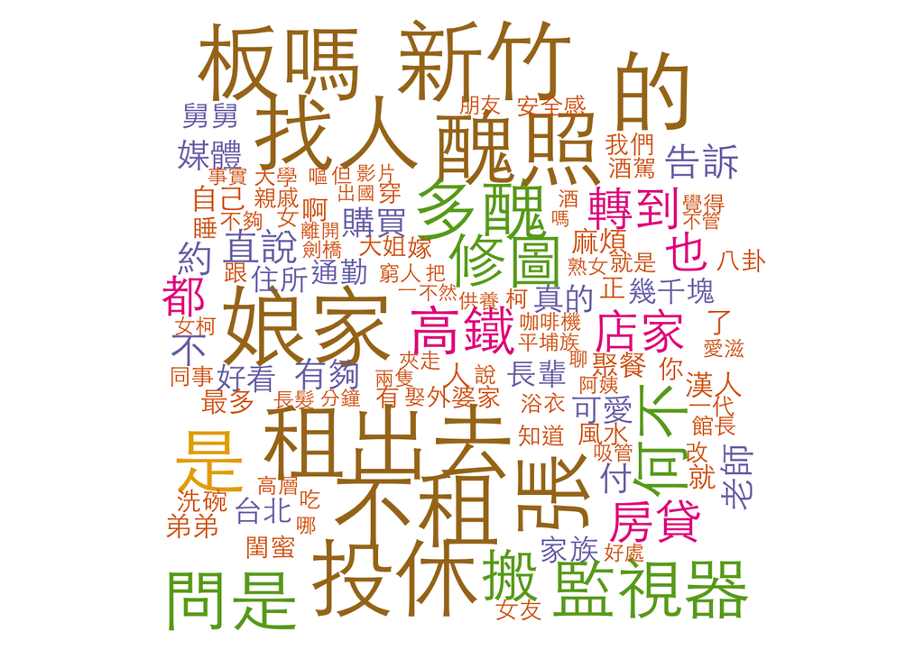

```r
library(wordcloud)
# mac 的使用者要加上這行，避免文字出不來的問題
par(family=("Heiti TC Light"))

f <- sort(rowSums(docs.tfidf), decreasing = T)
docs.df <- data.frame(
  word = names(f),
  freq = f
)
wordcloud(docs.df$word[1:120], docs.df$freq[1:120], scale=c(5,0.1), colors=brewer.pal(8, "Dark2"))
```

### Principal components analysis，PCA

> 是一種可幫助我們使用最有影響力的特徵做資料操作的分析模型，也可以說是特徵提取的技術，透過特徵降維來避免因維度災難所造成 Overfitting 現象。

```r
# install.packages("factoextra")
library(factoextra)
```

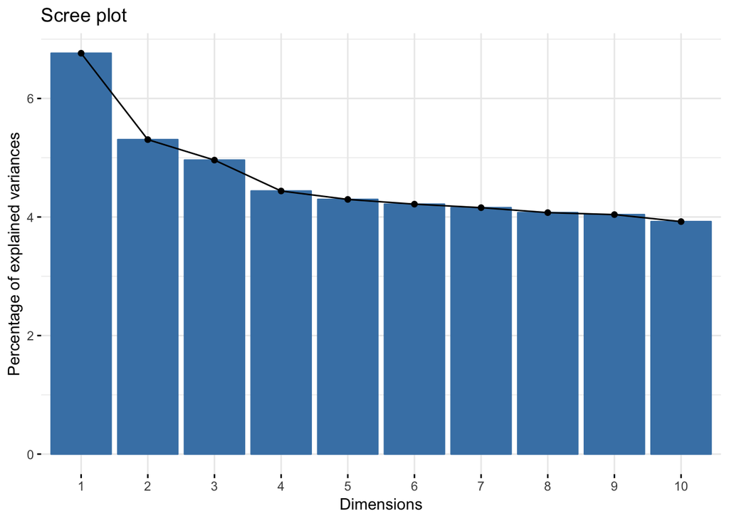

```r
docs.pca <- prcomp(docs.tfidf, scale = T)
fviz_eig(docs.pca)
```

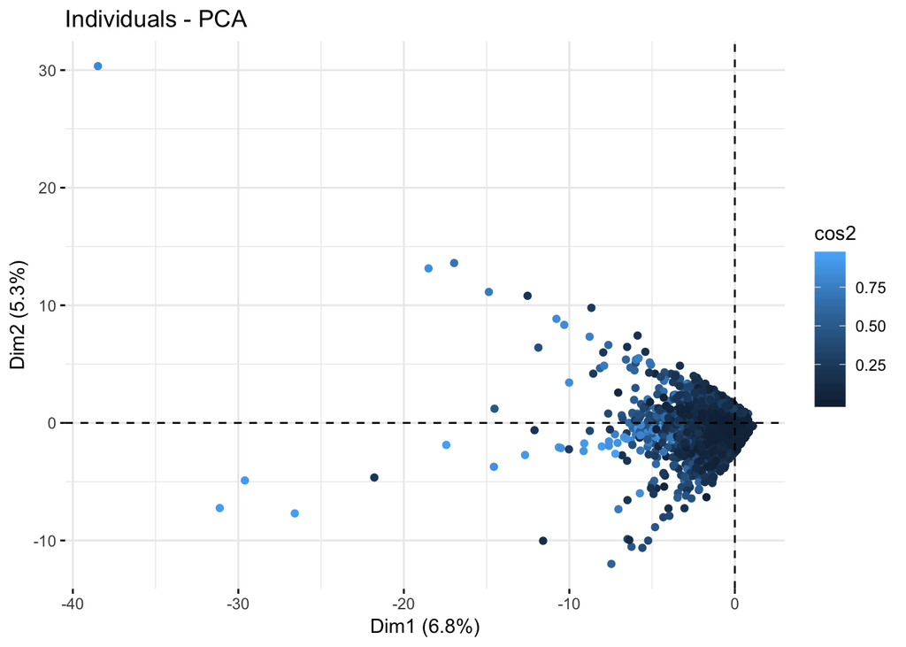

```r
fviz_pca_ind(docs.pca, geom.ind = c("point"), col.ind = "cos2")
```

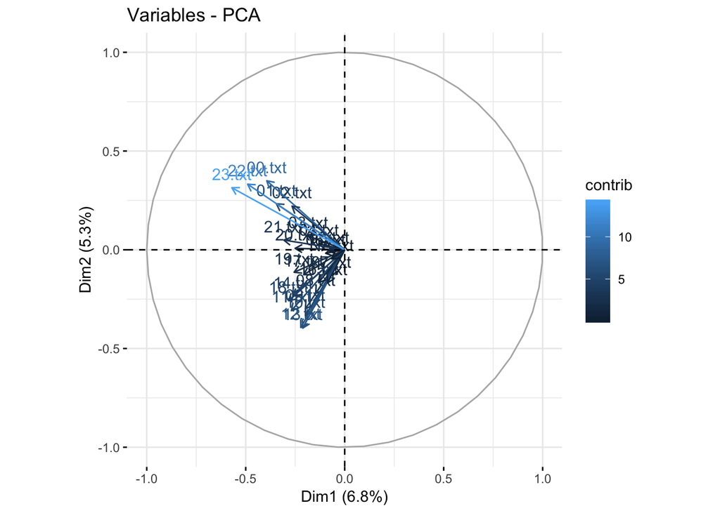

```r
fviz_pca_var(docs.pca, col.var = "contrib")
```

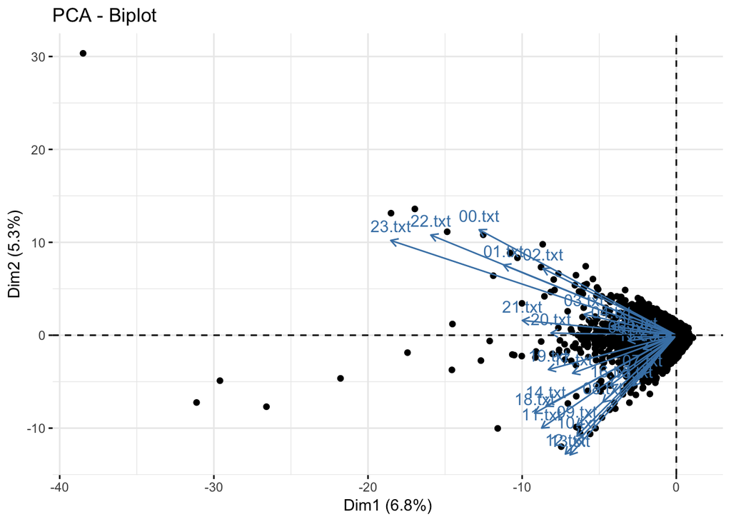

```r
fviz_pca_biplot(docs.pca, geom.ind = "point")
```

```r
docs.eig <- get_eig(docs.pca)
docs.var <- get_pca_var(docs.pca)
docs.ind <- get_pca_ind(docs.pca)
```

### K-Means

> 物以類聚，給定一組資料，將它分成 k 類。主要目標是在大量資料點中找出具有代表性的資料點。

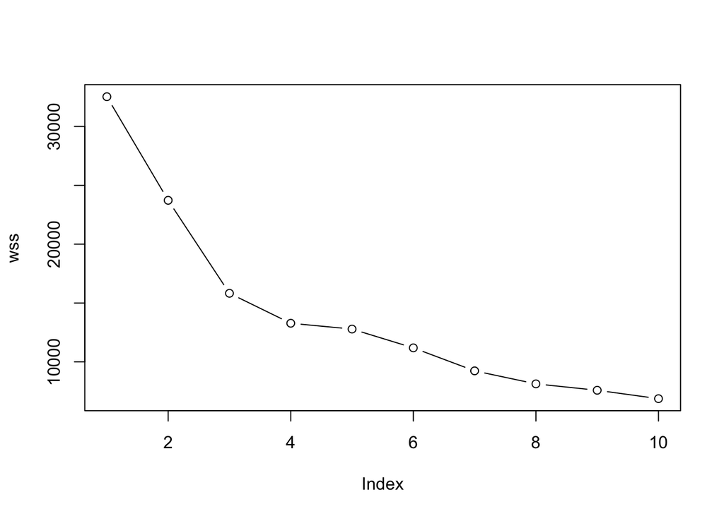

```r
ind.coord2 <- docs.ind$coord[, c(3,4)]
wss <- c()
for (i in 1:10) { wss[i] <- kmeans(ind.coord2, i)$tot.withinss }
plot(wss, type = "b")
```

[參考資料](https://www.hksilicon.com/articles/1445347)

根據上圖，隨著聚類數目增多，每一個類別中數量越來越少，距離越來越近，因此 WSS 值肯定是隨着聚類數目增多而減少的，所以我們需要關注的是斜率的變化，但 WWS 減少得很緩慢時，就認為進一步增大聚類數效果也並不能增強，存在得這個「肘點」就是最佳聚類數目，從一類到三類下降得很快，之後下降得很慢，所以最佳聚類 k 個數選為 3。

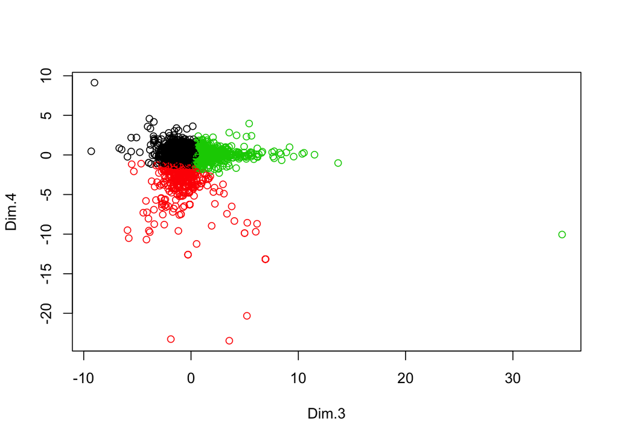

```r
km <- kmeans(ind.coord2, 3)
plot(ind.coord2, col = km$cluster)
points(km$centers, col = 1:3, pch = 8, cex = 2)
```

### References

- R 軟體爬蟲和⽂字斷詞 http://biostat.tmu.edu.tw/enews/ep_download/21rb.pdf
- 中文文本探勘初探：TF-IDF in R Language http://mropengate.blogspot.com/2016/04/tf-idf-in-r-language.html
- K means 演算法 https://dotblogs.com.tw/dragon229/2013/02/04/89919
- R筆記–(9)分群分析(Clustering) https://rpubs.com/skydome20/R-Note9-Clustering